# Lab 4b

Statistical inference, bootstrap

Utrecht Summer School: Statistical Programming with R

# 1 Bootstrap

In this exercise we you will work with the bootstrap function presented in the lecture slides.

## 1.1 Load the necessary packages

Load the packages: `tidyverse`, `ggplot2` and `patchwork`. The package `pacman` helps to manage loading your packages.

## 1.2 Create an R script for the bootstrap function using the following steps:

- Open an R script in RStudio with: File -> New File -> R Script
- Copy-paste the bootstrap function from the lecture in the R script file and save it as `my_bootstrap`,
- Source the `my_bootstrap` file by running the the in the R chunk below. Check if the function appeared in your workspace.

```r
source("my_bootstrap.R")
```

## 1.3 Load the data

Load the mammals sleep data with the `load()` function. The data are in the folder “Lecture and Lab 4b” and are in the R data format (extension .Rdata). Check whether you see the data in the workspace.

```r
load("MammalsSleepData.RData")
```

## 1.4 Inspect the data

Have a quick inspection of the data with `glimpse()` or `str()` and look at the descriptive statistics with `summary()`

```r
glimpse(mammals)
```

```
Rows: 62
Columns: 11
$ species      <fct> Africanelephant, Africangiantpouchedrat, ArcticFox, Arcticgroundsquirrel, Asianelephan…
$ body_wt      <dbl> 6654.000, 1.000, 3.385, 0.920, 2547.000, 10.550, 0.023, 160.000, 3.300, 52.160, 0.425,…
$ brain_wt     <dbl> 5712.00, 6.60, 44.50, 5.70, 4603.00, 179.50, 0.30, 169.00, 25.60, 440.00, 6.40, 423.00…
$ non_dreaming <dbl> NA, 6.3, NA, NA, 2.1, 9.1, 15.8, 5.2, 10.9, 8.3, 11.0, 3.2, 7.6, NA, 6.3, 8.6, 6.6, 9.…
$ dreaming     <dbl> NA, 2.0, NA, NA, 1.8, 0.7, 3.9, 1.0, 3.6, 1.4, 1.5, 0.7, 2.7, NA, 2.1, 0.0, 4.1, 1.2, …
$ total_sleep  <dbl> 3.3, 8.3, 12.5, 16.5, 3.9, 9.8, 19.7, 6.2, 14.5, 9.7, 12.5, 3.9, 10.3, 3.1, 8.4, 8.6, …
$ life_span    <dbl> 38.6, 4.5, 14.0, NA, 69.0, 27.0, 19.0, 30.4, 28.0, 50.0, 7.0, 30.0, NA, 40.0, 3.5, 50.…
$ gestation    <dbl> 645.0, 42.0, 60.0, 25.0, 624.0, 180.0, 35.0, 392.0, 63.0, 230.0, 112.0, 281.0, NA, 365…
$ predation    <int> 3, 3, 1, 5, 3, 4, 1, 4, 1, 1, 5, 5, 2, 5, 1, 2, 2, 2, 1, 1, 5, 5, 3, 1, 1, 1, 5, 5, 5,…
$ exposure     <int> 5, 1, 1, 2, 5, 4, 1, 5, 2, 1, 4, 5, 1, 5, 1, 2, 2, 2, 2, 1, 5, 5, 1, 4, 3, 1, 1, 3, 5,…
$ danger       <int> 3, 3, 1, 3, 4, 4, 1, 4, 1, 1, 4, 5, 2, 5, 1, 2, 2, 2, 1, 1, 5, 5, 2, 1, 1, 1, 3, 4, 5,…
```

```r
# str(mammals)
```

```r
summary(mammals)
```

```
                   species      body_wt            brain_wt        non_dreaming       dreaming
 Africanelephant       : 1   Min.   :   0.005   Min.   :   0.14   Min.   : 2.100   Min.   :0.000
 Africangiantpouchedrat: 1   1st Qu.:   0.600   1st Qu.:   4.25   1st Qu.: 6.250   1st Qu.:0.900
 ArcticFox             : 1   Median :   3.342   Median :  17.25   Median : 8.350   Median :1.800
 Arcticgroundsquirrel  : 1   Mean   : 198.790   Mean   : 283.13   Mean   : 8.673   Mean   :1.972
 Asianelephant         : 1   3rd Qu.:  48.202   3rd Qu.: 166.00   3rd Qu.:11.000   3rd Qu.:2.550
 Baboon                : 1   Max.   :6654.000   Max.   :5712.00   Max.   :17.900   Max.   :6.600
 (Other)               :56                                        NA's   :14       NA's   :12
  total_sleep      life_span         gestation        predation        exposure         danger
 Min.   : 2.60   Min.   :  2.000   Min.   : 12.00   Min.   :1.000   Min.   :1.000   Min.   :1.000
 1st Qu.: 8.05   1st Qu.:  6.625   1st Qu.: 35.75   1st Qu.:2.000   1st Qu.:1.000   1st Qu.:1.000
 Median :10.45   Median : 15.100   Median : 79.00   Median :3.000   Median :2.000   Median :2.000
 Mean   :10.53   Mean   : 19.878   Mean   :142.35   Mean   :2.871   Mean   :2.419   Mean   :2.613
 3rd Qu.:13.20   3rd Qu.: 27.750   3rd Qu.:207.50   3rd Qu.:4.000   3rd Qu.:4.000   3rd Qu.:4.000
 Max.   :19.90   Max.   :100.000   Max.   :645.00   Max.   :5.000   Max.   :5.000   Max.   :5.000
 NA's   :4       NA's   :4         NA's   :4
```

## 1.5 Create a subset of the data

Create a subset of the data with only the variables: `total_sleep`, `brain_wt`, `body_wt` and `danger`, and remove the missing values (hint: use the pipe operator).

```r
subset_mammals <- mammals %>%
  select(total_sleep, brain_wt, body_wt, danger) %>%
  na.omit()
```

## 1.6 Create a new variable

```r
subset_mammals <- subset_mammals %>%
  dplyr::mutate(brain_body = brain_wt / body_wt)
```

## 1.7 Fit a linear model

```r
fit_mammals <- lm(total_sleep ~ brain_body + danger, data = subset_mammals)
```

Display the summary of this linear model and save it. What do you conclude about the results?

```r
sum_fit_mammals <- summary(fit_mammals)
sum_fit_mammals
```

```
Call:
lm(formula = total_sleep ~ brain_body + danger, data = subset_mammals)

Residuals:
    Min      1Q  Median      3Q     Max
-7.4597 -2.6697 -0.3945  2.9221  7.1482

Coefficients:
            Estimate Std. Error t value Pr(>|t|)
(Intercept) 14.40733    1.25438  11.486 3.10e-16 ***
brain_body   0.08095    0.05572   1.453    0.152
danger      -1.85235    0.36005  -5.145 3.69e-06 ***
---
Signif. codes:  0 '***' 0.001 '**' 0.01 '*' 0.05 '.' 0.1 ' ' 1

Residual standard error: 3.723 on 55 degrees of freedom
Multiple R-squared:  0.3696,    Adjusted R-squared:  0.3467
F-statistic: 16.13 on 2 and 55 DF,  p-value: 3.082e-06
```

Obtain the 95% confidence intervals for the regression coefficients of the linear model and save the results.

```r
CI95 <- confint(fit_mammals)
CI95
```

```
                  2.5 %    97.5 %
(Intercept) 11.89349587 16.921166
brain_body  -0.03071524  0.192613
danger      -2.57390594 -1.130794
```

## 1.8 Run the bootstrap

Run the bootstrap function on the same linear regression model as in the previous question. Save the results as `boot_mammals`. Do not forget to set a random number seed.

```r
set.seed(848)
boot_mammals <- bootstrap(total_sleep ~ brain_body + danger, data = subset_mammals)
```

## 1.9 Visualize the bootstrap distributions

Make a histogram of the bootstrap distributions for the predictors `brain_body` and `danger` using the package `ggplot2`.

The package `ggplot2` works best with data frames. The output of the bootstrap function, `boot_mammals` is a list. Convert the list into a data frame first.

```r
# Make dataframe from the list of bootstrap coefficients
df_boot_mammals <- data.frame(boot_mammals)
```

Make a histogram of the bootstrap distribution for the regression coefficient of `brain_body` and for `danger` with `ggplot2`.

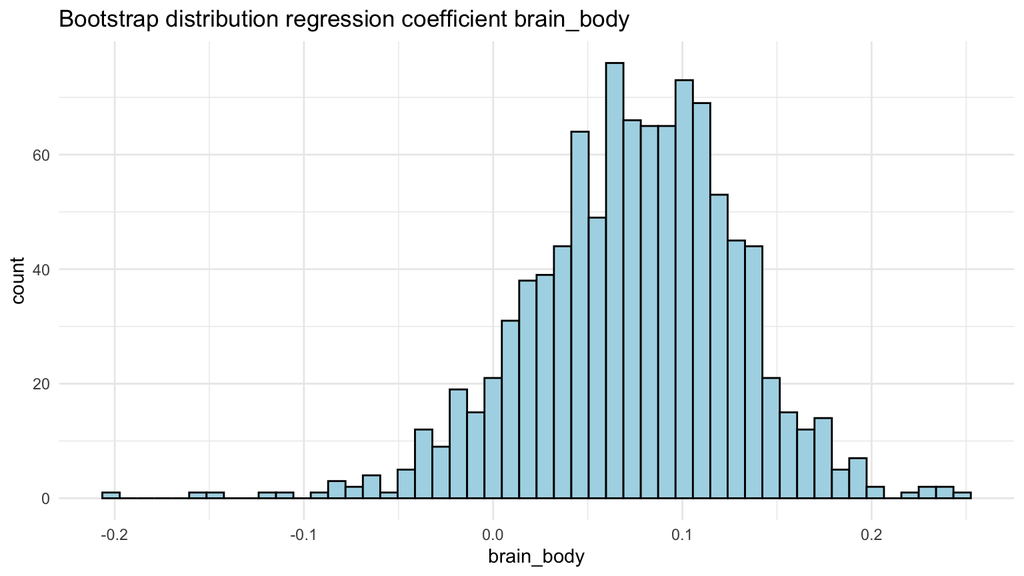

```r
df_boot_mammals %>%
  ggplot(aes(brain_body)) +
  geom_histogram(bins = 50, fill = "lightblue", color = "black") +
  theme_minimal() +
  labs(
    title = "Bootstrap distribution regression coefficient brain_body")
```

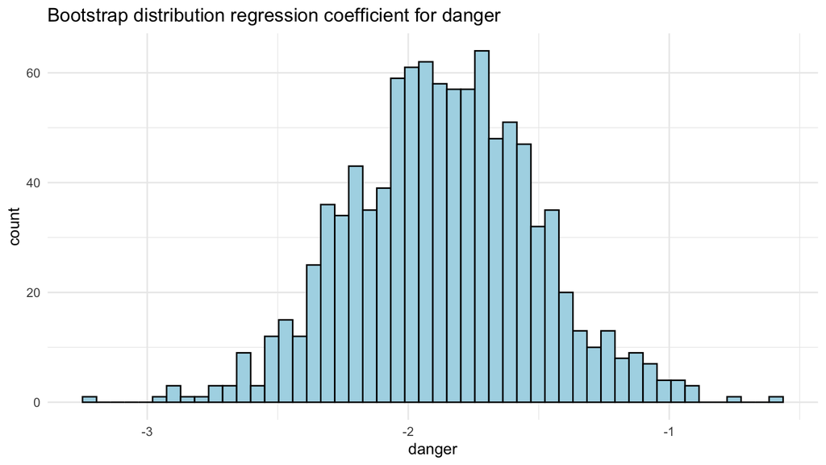

```r
df_boot_mammals %>%
  ggplot(aes(danger)) +
  geom_histogram(bins = 50, fill = "lightblue", color = "black") +
  theme_minimal() +
  labs(
    title = "Bootstrap distribution regression coefficient for danger")
```

## 1.10 Compare the confidence intervals

First write code to obtain the bootstrap percentile 95% confidence intervals (see code in the lecture slide) and save the results:

```r
CI95_boot <- apply(boot_mammals, 2, function(x) quantile(x, probs = c(.025, .975))) %>% t()
CI95_boot %>% round(3)
```

```
              2.5%  97.5%
(Intercept) 11.627 17.136
brain_body  -0.038  0.176
danger      -2.550 -1.123
```

Display the results of the theoretical 95% confidence interval you obtained earlier.

```r
CI95 %>% round(3)
```

```
             2.5 % 97.5 %
(Intercept) 11.893 16.921
brain_body  -0.031  0.193
danger      -2.574 -1.131
```

Then compare the bootstrap 95% CI and the theoretical 95% CI. What do the results tell you bout the tenability of the model assumptions?

```r
(CI95_boot  - CI95) %>% round(3)
```

```
              2.5%  97.5%
(Intercept) -0.267  0.215
brain_body  -0.007 -0.017
danger       0.024  0.008
```

# 2 Advanced

## 2.1 Make more advanced plots

### 2.1.1 Plot the confidence intervals in the bootstrap distribution

In a previous exercise you created histograms of the bootstrap distribution of the regression coefficients for `brain_body` and `danger`. Use the same histograms and add to the plots as vertical lines:

- the limits for the theoretical and bootstrap 95% confidence intervals.
- the mean of the bootstrapped regression coefficients.
- the values of the regression coefficients of the fitted model.

With the option `geom_vline()` you can add vertical lines to your plot.

The package `patchwork` allows you to display two plots in one figure by simply adding a `+` sign between the two plots.

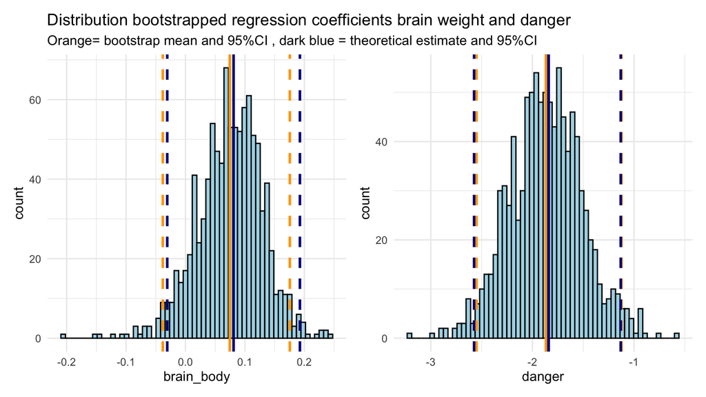

```r
library(patchwork)
df_boot_mammals %>%
  ggplot(aes(brain_body)) +
  geom_histogram(bins = 60, fill = "lightblue", color = "black") +
  geom_vline(xintercept = fit_mammals$coefficients[[2]], col = "darkblue", linewidth = 1) +
  geom_vline(xintercept = mean(df_boot_mammals$brain_body), col = "orange", linewidth = 1) +
  geom_vline(xintercept = CI95_boot[2,1], col = "orange", linewidth = 1, linetype = "dashed") +
  geom_vline(xintercept = CI95_boot[2,2], col = "orange", linewidth = 1, linetype = "dashed") +
  geom_vline(xintercept = CI95[2,1], col = "darkblue", linewidth = 1, linetype = "dashed") +
  geom_vline(xintercept = CI95[2,2], col = "darkblue", linewidth = 1, linetype = "dashed") +
  theme_minimal() +
  labs(
    title = "Distribution bootstrapped regression coefficients brain weight and danger",
    subtitle = "Orange= bootstrap mean and 95%CI , dark blue = theoretical estimate and 95%CI") +

df_boot_mammals %>%
  ggplot(aes(danger)) +
  geom_histogram(bins = 60, fill = "lightblue", color = "black") +
  geom_vline(xintercept = fit_mammals$coefficients[[3]], col = "darkblue", linewidth = 2) +
  geom_vline(xintercept = mean(df_boot_mammals$danger), col = "orange", linewidth = 1) +
  geom_vline(xintercept = CI95_boot[3,1], col = "orange", linewidth = 1, linetype = "dashed") +
  geom_vline(xintercept = CI95_boot[3,2], col = "orange", linewidth = 1, linetype = "dashed") +
  geom_vline(xintercept = CI95[3,1], col = "darkblue", linewidth = 1, linetype = "dashed") +
  geom_vline(xintercept = CI95[3,2], col = "darkblue", linewidth = 1, linetype = "dashed") +
  theme_minimal()
```

## 2.2 Plot the theoretical and bootstrap distributions

In a 1 x 2 plot array, plot the bootstrap sampling distributions of the regression coefficients two variables `brain_body` and `danger` in red, and the theoretical sampling distribution of the regression coefficients in blue. For the latter, use `stat_function(fun = dnorm, args = list(mean = ..., sd = ...))`, with the arguments `mean` and `sd` derived from the corresponding parameter estimates of the `lm` model. Use the `fit_mammals` and the `sum_fit_mammals` objects to obtain the statistics you need for the plots.

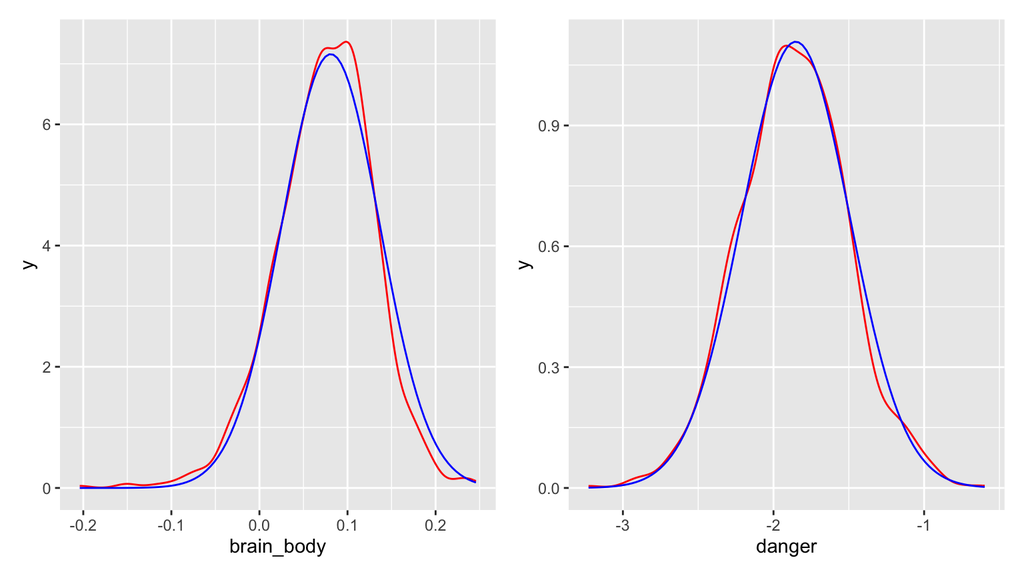

```r
ggplot(df_boot_mammals, aes(x = brain_body)) +
  geom_density(col = "red") +
  stat_function(fun = dnorm, args = list(mean = fit_mammals$coef[2],
                                         sd = sum_fit_mammals$coefficients[2, 2]),
                col = "blue") +

ggplot(df_boot_mammals, aes(x = danger)) +
  geom_density(col = "red") +
  stat_function(fun = dnorm, args = list(mean = fit_mammals$coef[3],
                                         sd = sum_fit_mammals$coefficients[3, 2]),
                col = "blue")
```

## 2.3 Add more functionality to the bootstrap function

Modify the `bootstrap()` function in such a way that instead of the bootstrapped parameters it returns

```
-   the bootstrap confidence intervals of the parameters and of the R-squared
-   a plot of the R-squared sampling distribution
```

```r
bootstrap <- function(formula, data, B = 1000) {

  pars    <- colnames(model.matrix(formula, data = data))

  output  <- matrix(nrow = B, ncol = length(pars) + 1,
                    dimnames = list(NULL, c(pars, "Rsquared")))

  for (i in 1:B) {
    bootsample  <- slice_sample(.data = data, n = nrow(data), replace = TRUE)
    bootfit     <- lm(formula = formula, data = bootsample)
    output[i, ] <- c(bootfit$coef, summary(bootfit)$r.squared)
  }

  return(list(confint = apply(output, 2, function(x) quantile(x, probs = c(.025, .975))),
              gg_rsq  = ggplot(as.data.frame(output), aes(Rsquared)) + geom_density()))
}
```

Apply the `bootstrap` function to a model and data set of your own choice.

```r
bootstrap(price ~ carat + cut,
          mutate(diamonds, cut = factor(cut, ordered = F)) %>%
            slice_sample(n = 2500))
```

```
$confint
      (Intercept)    carat   cutGood cutVery Good cutPremium cutIdeal  Rsquared
2.5%    -4264.547 7553.608  494.1678     749.4291   740.4844 1282.622 0.8379751
97.5%   -3183.367 7975.133 1592.6584    1843.7781  1845.0708 2348.244 0.8643773

$gg_rsq
```

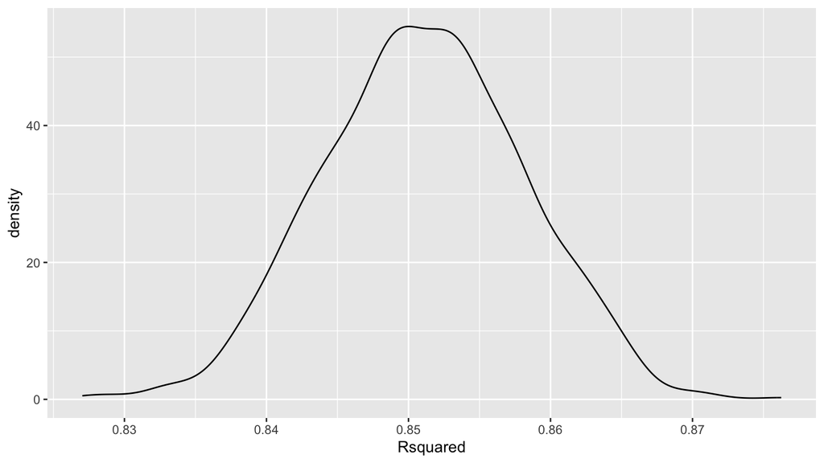